# Week 7

Check for multicollinearity - we noticed some high correlations in the scatterplots and correlation matrix didn’t we?

```r
# Calculate Variance Inflation Factors (VIF)
library(car)
vif(lm.fit1)
```

```
##    cylinders displacement   horsepower       weight acceleration         year
##    10.737535    21.836792     9.943693    10.831260     2.625806     1.244952
##       origin
##     1.772386
```

```r
library(sf)
library(dplyr)
Auto.1 <- as.data.frame(Auto)

Auto.1 <- Auto.1 %>%
  mutate(cylinders = as.character(cylinders))

model.exp <- lm(mpg ~ year + origin + weight + horsepower + weight*horsepower + cylinders, data = Auto.1)
summary(model.exp)
```

```
##
## Call:
## lm(formula = mpg ~ year + origin + weight + horsepower + weight *
##     horsepower + cylinders, data = Auto.1)
##
## Residuals:
##     Min      1Q  Median      3Q     Max
## -6.9852 -1.5502 -0.1461  1.5546 11.9173
##
## Coefficients:
##                     Estimate Std. Error t value Pr(>|t|)
## (Intercept)       -6.487e+00  4.300e+00  -1.509 0.132244
## year               7.528e-01  4.377e-02  17.197  < 2e-16 ***
## origin             8.196e-01  2.336e-01   3.509 0.000504 ***
## weight            -1.023e-02  7.559e-04 -13.531  < 2e-16 ***
## horsepower        -1.917e-01  2.128e-02  -9.009  < 2e-16 ***
## cylinders4         6.061e+00  1.481e+00   4.093 5.19e-05 ***
## cylinders5         8.303e+00  2.222e+00   3.738 0.000214 ***
## cylinders6         5.166e+00  1.537e+00   3.362 0.000853 ***
## cylinders8         6.423e+00  1.649e+00   3.895 0.000116 ***
## weight:horsepower  4.719e-05  5.489e-06   8.597  < 2e-16 ***
## ---
## Signif. codes:  0 '***' 0.001 '**' 0.01 '*' 0.05 '.' 0.1 ' ' 1
##
## Residual standard error: 2.853 on 382 degrees of freedom
## Multiple R-squared:  0.8694, Adjusted R-squared:  0.8663
## F-statistic: 282.6 on 9 and 382 DF,  p-value: < 2.2e-16
```

as.factor could replace as.character for number variables

```r
model.exp2 <- lm(mpg ~ year + origin + weight + horsepower + weight*horsepower + as.factor(cylinders), data = Auto)
summary(model.exp2)
```

```
##
## Call:
## lm(formula = mpg ~ year + origin + weight + horsepower + weight *
##     horsepower + as.factor(cylinders), data = Auto)
##
## Residuals:
##     Min      1Q  Median      3Q     Max
## -6.9852 -1.5502 -0.1461  1.5546 11.9173
##
## Coefficients:
##                         Estimate Std. Error t value Pr(>|t|)
## (Intercept)           -6.487e+00  4.300e+00  -1.509 0.132244
## year                   7.528e-01  4.377e-02  17.197  < 2e-16 ***
## origin                 8.196e-01  2.336e-01   3.509 0.000504 ***
## weight                -1.023e-02  7.559e-04 -13.531  < 2e-16 ***
## horsepower            -1.917e-01  2.128e-02  -9.009  < 2e-16 ***
## as.factor(cylinders)4  6.061e+00  1.481e+00   4.093 5.19e-05 ***
## as.factor(cylinders)5  8.303e+00  2.222e+00   3.738 0.000214 ***
## as.factor(cylinders)6  5.166e+00  1.537e+00   3.362 0.000853 ***
## as.factor(cylinders)8  6.423e+00  1.649e+00   3.895 0.000116 ***
## weight:horsepower      4.719e-05  5.489e-06   8.597  < 2e-16 ***
## ---
## Signif. codes:  0 '***' 0.001 '**' 0.01 '*' 0.05 '.' 0.1 ' ' 1
##
## Residual standard error: 2.853 on 382 degrees of freedom
## Multiple R-squared:  0.8694, Adjusted R-squared:  0.8663
## F-statistic: 282.6 on 9 and 382 DF,  p-value: < 2.2e-16
```

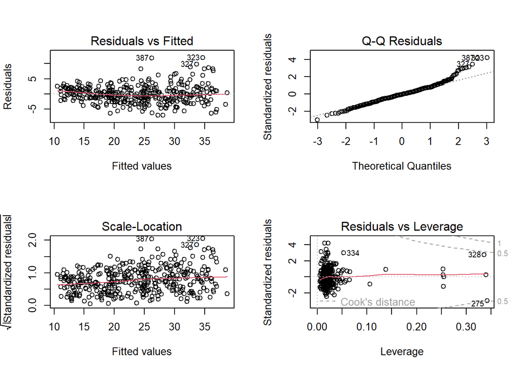

```r
par(mfrow = c(2, 2))
plot(model.exp2)
```

```r
vif(model.exp2)
```

```
## there are higher-order terms (interactions) in this model
## consider setting type = 'predictor'; see ?vif
```

```
##                           GVIF Df GVIF^(1/(2*Df))
## year                  1.248672  1        1.117440
## origin                1.700595  1        1.304069
## weight               19.796541  1        4.449330
## horsepower           32.233547  1        5.677460
## as.factor(cylinders)  9.467761  4        1.324436
## weight:horsepower    70.165814  1        8.376504
```

Holy Moses. There are some concerning VIFs. Like displacement. That looks like a bad banana.

```r
model2 <- lm(mpg ~ displacement + weight +acceleration + year + origin, data = Auto)
summary(model2)
```

```
##
## Call:
## lm(formula = mpg ~ displacement + weight + acceleration + year +
##     origin, data = Auto)
##
## Residuals:
##     Min      1Q  Median      3Q     Max
## -9.3110 -2.1671 -0.0526  1.8293 13.0061
##
## Coefficients:
##                Estimate Std. Error t value Pr(>|t|)
## (Intercept)  -2.054e+01  4.133e+00  -4.970 1.01e-06 ***
## displacement  1.060e-02  5.398e-03   1.963   0.0503 .
## weight       -6.904e-03  5.799e-04 -11.904  < 2e-16 ***
## acceleration  1.522e-01  7.782e-02   1.956   0.0512 .
## year          7.639e-01  4.978e-02  15.344  < 2e-16 ***
## origin        1.319e+00  2.702e-01   4.881 1.55e-06 ***
## ---
## Signif. codes:  0 '***' 0.001 '**' 0.01 '*' 0.05 '.' 0.1 ' ' 1
##
## Residual standard error: 3.334 on 386 degrees of freedom
## Multiple R-squared:  0.8199, Adjusted R-squared:  0.8175
## F-statistic: 351.4 on 5 and 386 DF,  p-value: < 2.2e-16
```

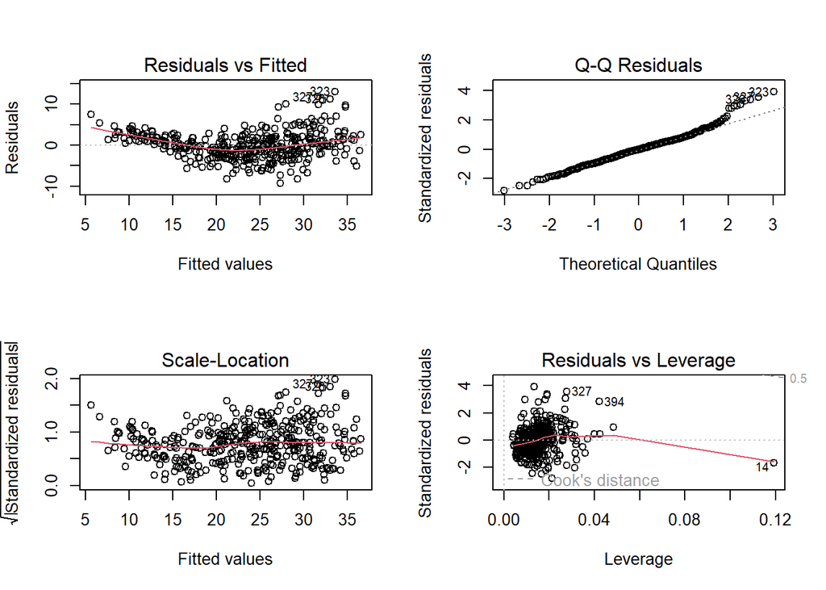

```r
par(mfrow = c(2, 2))
plot(model2)
```

```r
vif(model2)
```

```
## displacement       weight acceleration         year       origin
##    11.222526     8.536558     1.621733     1.183144     1.666322
```

How about just include weight as it is the most strongly correlated of the three, but try to use a squared term?

```r
model3 <- lm(mpg ~ I(weight^2) +acceleration + year + origin, data = Auto)
summary(model3)
```

```
##
## Call:
## lm(formula = mpg ~ I(weight^2) + acceleration + year + origin,
##     data = Auto)
##
## Residuals:
##    Min     1Q Median     3Q    Max
## -9.620 -2.419 -0.151  1.895 13.292
##
## Coefficients:
##                Estimate Std. Error t value Pr(>|t|)
## (Intercept)  -2.907e+01  4.226e+00  -6.880 2.41e-11 ***
## I(weight^2)  -8.298e-07  4.437e-08 -18.702  < 2e-16 ***
## acceleration  1.045e-01  7.486e-02   1.396    0.163
## year          7.398e-01  5.360e-02  13.802  < 2e-16 ***
## origin        1.673e+00  2.737e-01   6.112 2.41e-09 ***
## ---
## Signif. codes:  0 '***' 0.001 '**' 0.01 '*' 0.05 '.' 0.1 ' ' 1
##
## Residual standard error: 3.634 on 387 degrees of freedom
## Multiple R-squared:  0.7855, Adjusted R-squared:  0.7833
## F-statistic: 354.2 on 4 and 387 DF,  p-value: < 2.2e-16
```

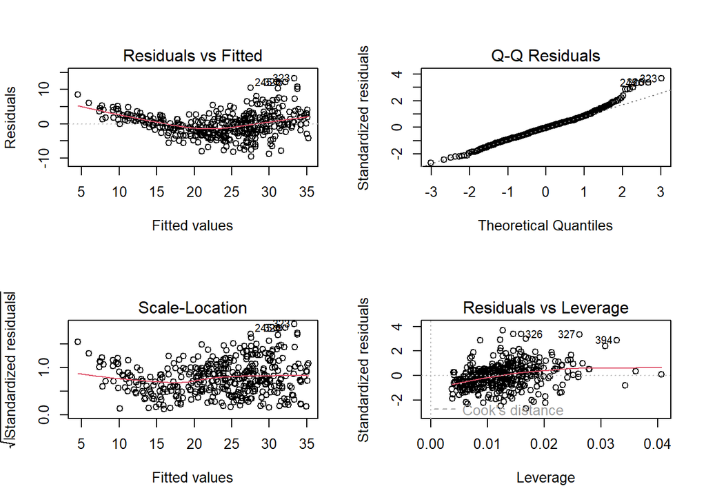

```r
par(mfrow = c(2, 2))
plot(model3)
```

```r
vif(model3)
```

```
##  I(weight^2) acceleration         year       origin
##     1.747247     1.263275     1.154618     1.439680
```

Look for outliers that are problematic (bad bananas)

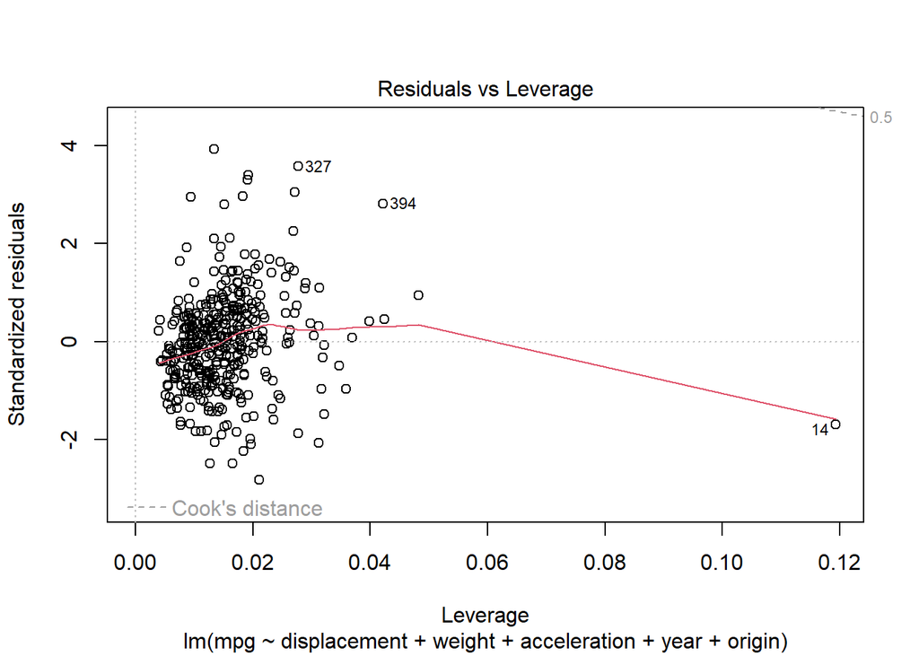

```r
# Plot standardized residuals vs. leverage
plot(model2, which = 5)
```

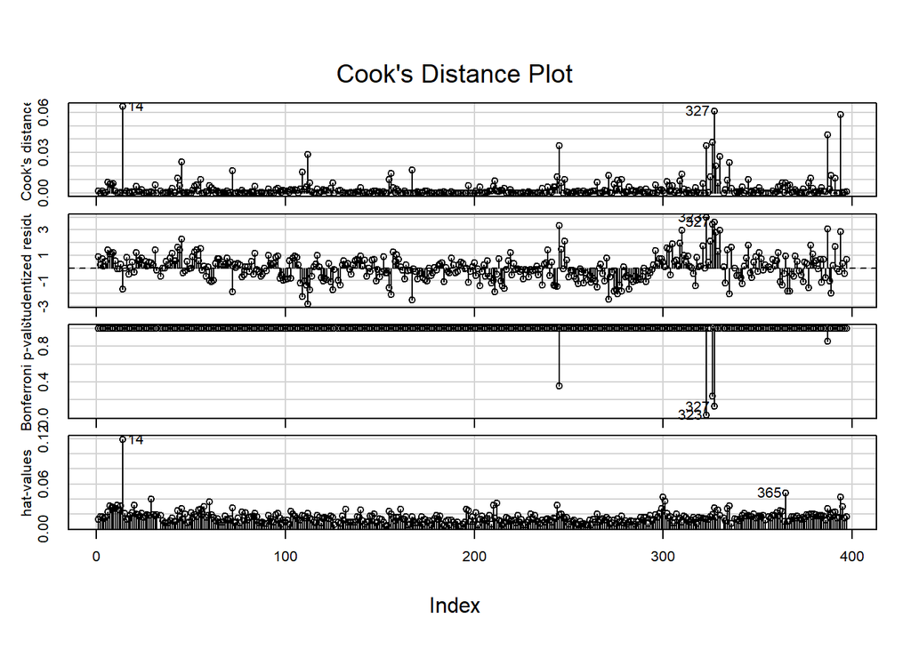

```r
# Identify influential points using Cook's distance
influenceIndexPlot(model2, id.method = "identify", main = "Cook's Distance Plot")
```

Check for high leverage outliers

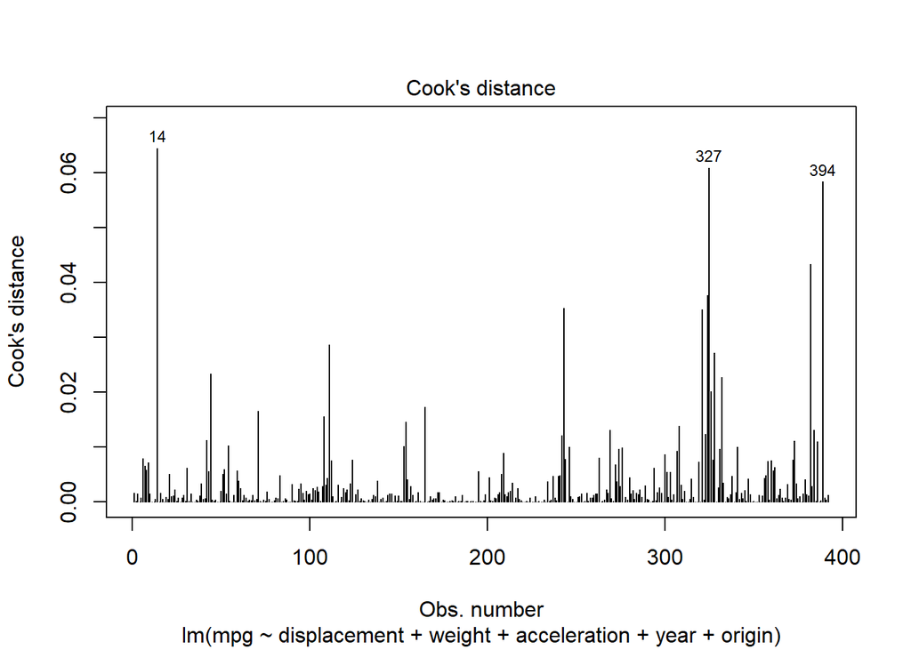

```r
plot(model2, which = 4)
```

You could take a dive and look into that observation number 327. You could remove it and run the regression with it and without it to see if its ruining your life. If it were data you were more familiar with, investigate to see what’s going on..

# 2 Exploring Validation and Cross Validation.

Adapted from: https://hastie.su.domains/ISLR2/Labs/Rmarkdown_Notebooks/Ch5-resample-lab.Rmd

We will begin by trying old plain old validation. We will split the data into two halves by selecting a random subset of 196 observations out of the original 392.

Whenever we do something that involves random values to be selected, it is a good practice to set the ‘seed’ using set.seed(). This will ensure that you will get the same value each time and ensure that your analysis is reproducible.

We will use the ‘sample()’ function to randomly split the data into the training and testing dataset.

```r
set.seed(1) #ensures we get the same set of randomly set data when we re-run the code
train <- sample(392, 196)
```

We then use the `subset` option in `lm()` to fit a linear regression using only the observations corresponding to the training set.

```r
lm.fit <- lm(mpg ~ horsepower, data = Auto, subset = train)
```

We now use the ‘predict()’ function to estimate the response for all $392$ observations, and we use the ‘mean()’ function to calculate the MSE of the $196$ observations in the validation set. Note that the ‘-train’ index below selects only the observations that are not in the training set.

We get the MSE by subtracting the original value for the testing data from the predicted value. We square that value so the negative and positive errors don’t cancel each other out!

```r
attach(Auto)
mean((mpg - predict(lm.fit, Auto))[-train]^2)
```

```
## [1] 23.26601
```

Therefore, the estimated test MSE for the linear regression fit is $23.27$. We can use the poly() function to estimate the test error for the quadratic and cubic regressions.

```r
lm.fit2 <- lm(mpg ~ poly(horsepower, 2), data = Auto,
    subset = train)
mean((mpg - predict(lm.fit2, Auto))[-train]^2)
```

```
## [1] 18.71646
```

```r
lm.fit3 <- lm(mpg ~ poly(horsepower, 3), data = Auto,
    subset = train)
mean((mpg - predict(lm.fit3, Auto))[-train]^2)
```

```
## [1] 18.79401
```

These error rates are $18.72$ and $18.79$, respectively. If we choose a different training set instead, then we will obtain somewhat different errors on the validation set.

```r
set.seed(2) #using a different random number generator
train <- sample(392, 196)
lm.fit <- lm(mpg ~ horsepower, subset = train)
mean((mpg - predict(lm.fit, Auto))[-train]^2)
```

```
## [1] 25.72651
```

```r
lm.fit2 <- lm(mpg ~ poly(horsepower, 2), data = Auto, #quadratic
    subset = train)
mean((mpg - predict(lm.fit2, Auto))[-train]^2)
```

```
## [1] 20.43036
```

```r
lm.fit3 <- lm(mpg ~ poly(horsepower, 3), data = Auto,
    subset = train)
mean((mpg - predict(lm.fit3, Auto))[-train]^2)
```

```
## [1] 20.38533
```

Using this split of the observations into a training set and a validation set, we find that the validation set error rates for the models with linear, quadratic, and cubic terms are $25.73$, $20.43$, and $20.39$, respectively.

These results are consistent with our previous findings: a model that predicts `mpg` using a quadratic function of `horsepower` performs better than a model that involves only a linear function of `horsepower`, and there is little evidence in favor of a model that uses a cubic function of `horsepower`.

# Leave-One-Out Cross-Validation

The LOOCV estimate can be automatically computed for any generalized linear model using the `glm()` and `cv.glm()` functions.

We will use the glm family of models soon to estimate other, non-linear regressions. But for now, it acts the same as the lm function if we just use the defaults.

```r
glm.fit <- glm(mpg ~ horsepower, data = Auto) #glm is the linear regression here
coef(glm.fit)
```

```
## (Intercept)  horsepower
##  39.9358610  -0.1578447
```

```r
lm.fit <- lm(mpg ~ horsepower, data = Auto)
coef(lm.fit)
```

```
## (Intercept)  horsepower
##  39.9358610  -0.1578447
```

We will perform linear regression using the `glm()` function rather than the `lm()` function because the former can be used together with `cv.glm()`. The `cv.glm()` function is part of the `boot` library.

```r
library(boot)
glm.fit <- glm(mpg ~ horsepower, data = Auto)
cv.err <- cv.glm(Auto, glm.fit)
cv.err$delta #delta is the difference between model trained on full data vs. model trained on subset data, we should aim for the two models to be similar
```

```
## [1] 24.23151 24.23114
```

The `cv.glm()` function produces a list with several components. The two numbers in the `delta` vector contain the cross-validation results. In this case the numbers are identical (up to two decimal places) and correspond to the LOOCV statistic.

‘delta’ refers to the difference in deviance between the full model (trained on all data) and a model trained on a subset of the data.

```r
cv.error <- rep(0, 10)
for (i in 1:10) {
  glm.fit <- glm(mpg ~ poly(horsepower, i), data = Auto)
  cv.error[i] <- cv.glm(Auto, glm.fit)$delta[1]
}
cv.error
```

```
##  [1] 24.23151 19.24821 19.33498 19.42443 19.03321 18.97864 18.83305 18.96115
##  [9] 19.06863 19.49093
```

We see a sharp drop in the estimated test MSE between the linear and quadratic fits, but then no clear improvement from using higher-order polynomials.

## $k$-Fold Cross-Validation

The `cv.glm()` function can also be used to implement $k$-fold CV. Below we use $k=10$, a common choice for $k$, on the `Auto` data set. We once again set a random seed and initialize a vector in which we will store the CV errors corresponding to the polynomial fits of orders one to ten.

```r
set.seed(17)
cv.error.10 <- rep(0, 10)
for (i in 1:10) {
  glm.fit <- glm(mpg ~ poly(horsepower, i), data = Auto)
  cv.error.10[i] <- cv.glm(Auto, glm.fit, K = 10)$delta[1]
}
cv.error.10
```

```
##  [1] 24.27207 19.26909 19.34805 19.29496 19.03198 18.89781 19.12061 19.14666
##  [9] 18.87013 20.95520
```

Notice that the computation time is shorter than that of LOOCV.We still see little evidence that using cubic or higher-order polynomial terms leads to lower test error than simply using a quadratic fit.

The end of Part 1 for week 7. Now we will turn to an intro spatial machine learning and the hedonic, house price model.